# Modelling: Part 2

Pieter-Jan Inghelbrecht

All figures shown in this notebook are saved under **output/modelling/part2/figures**. This analysis is presented in notebook format which makes it easy to share with others. You can find tis notebook under home_bias: **modelling_part_2.nb.html** or for the code in notebook format: **modelling_part_2.Rmd**. Everything is also available on [github](https://github.com/piinghel/home_bias) (platform to store code and allows for version control)

You can also find the original code (not in notebook) under **code/modelling_part2.R** or in my [github](https://github.com/piinghel/home_bias) repository. You can hide the code by clicking on the **Hide** buttom, but I recommend you read my code comments as it will help you in understanding the analysis.

This notebook looks at the the average log PD per rating grade and test whether there is a statistical difference in credit risk between home and non-home issuers that receive the same rating. To test this hypothesis, we make use of the two sided t-test, more precisely the **Welch’s t-test** is used as samples have unequal variances in most cases. Note that using the regular t-test would note change any of the finding presente in any signiciant way. This part corresponds with page 15 (description of the methods) and 29 (results) of the paper.

## Load libraries

```r
# clear environment
rm(list = ls())
# load libraries
library(tidyverse)
library(readxl)
library(lubridate)
library(plyr)
library(knitr)
# plotting
library(ggpubr)
library(patchwork)
#own functions
source("code/functions/compare_means.R")
#---------------------------
# Global parameters
PALETTE <- RColorBrewer::brewer.pal(n = 8, name = "Dark2")
STYLE <- "steelblue"
#---------------------------
```

## Import Data and make some minor transformations

```r
df <- read_excel("data/data_rating.xlsx", sheet = "Long") %>%
  # make everything lowercase
  dplyr::rename(
    date = Date,
    pd = PD,
    moodys = Moodys,
    sp = SP,
    region = Region,
    sector = Sector
  )
df <- df %>% mutate(
  # compute the log of probability of default (pd)
  pd_log = log(pd + 0.000001),
  # add 0.0000001 to prevent inf values
  year = lubridate::year(date),
  month = lubridate::month(date),
  sp = as.factor(ifelse(sp > 17, 17, sp)),
  moodys = as.factor(ifelse(moodys > 17, 17, moodys)),
  region = as.factor(region),
  sector = as.factor(sector),
  year = as.factor(year),
  month = as.factor(month)
)
# recode S&P
df$sp <- as.factor(mapvalues(
  df$sp,
  from = c("1","2", "3","4","5","6","7","8","9","10","11","12","13","14","15","16","17"
  ),
  to = c( "AAA","AA+","AA","AA-","A+","A","A-","BBB+","BBB","BBB-","BB+","BB","BB-","B+","B","B-","CCC+..."
  )
))
# recode Moodys
df$moodys <- as.factor(mapvalues(
  df$moodys,
  from = c("1","2", "3","4","5","6","7","8","9","10","11","12","13","14","15","16","17"
  ),
  to = c("Aaa","Aa1","Aa2","Aa3","A1","A2","A3","Baa1","Baa2","Baa3","Ba1","Ba2","Ba3","B1","B2","B3","Caa3..."
)
))
```

## Perform Welch t-test

### 1) Visual Analysis

It is always a good idea to visualize your results. By doing so ,you can verify whether your findings make sense. The function **compae_means** is an function I defined myself and can be found under **code/functions** or on [github](https://github.com/piinghel/home_bias/blob/master/code/functions/compare_means.R). Sometimes I add jitter (raw data points) on the figure to check whether the p-value I get makes sense, for example in the first figure for Moodys: Aaa.

```r
# to give an example (by default I assume variance are not equal which is mostly the case)
df %>% select(pd_log, region, moodys) %>% na.omit() %>%
  filter(moodys == "Aa1") %>% t.test(pd_log~ region, data=., var.equal=FALSE)
```

```
    Welch Two Sample t-test

data:  pd_log by region
t = 4.7064, df = 1.5364, p-value = 0.06845
alternative hypothesis: true difference in means is not equal to 0
95 percent confidence interval:
 -0.2665719  2.5172426
sample estimates:
mean in group Europe     mean in group US
           -5.788573            -6.913908
```

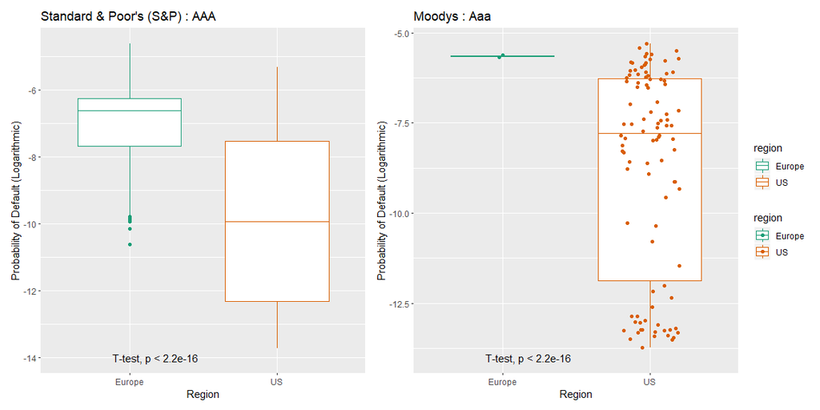

```r
# the code below does this for all ratings (both S&P and Moodys)
# 1)
compare_means(data = df,credit_agency = "sp",category = "AAA")$figure +
compare_means(data = df,credit_agency = "moodys",category = "Aaa", title = "Moodys", add="jitter")$figure +
  plot_layout(guides="collect")
```

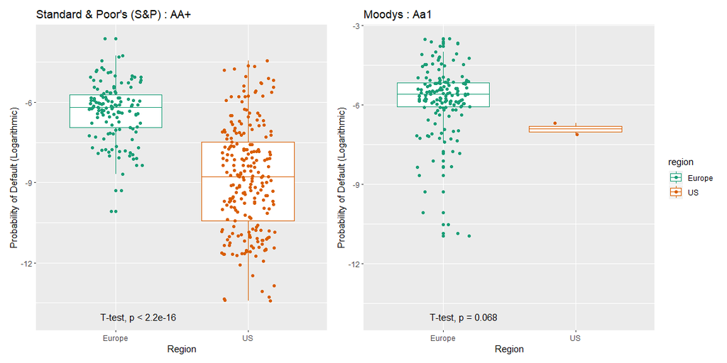

```r
ggsave("output/modelling/part2/figure1.png",  units = "cm",height = 10,width = 20)
# 2)
compare_means(data = df,credit_agency = "sp",category = "AA+", add="jitter")$figure +
compare_means(data = df,credit_agency = "moodys",category = "Aa1", title = "Moodys", add="jitter")$figure +
  plot_layout(guides="collect")
```

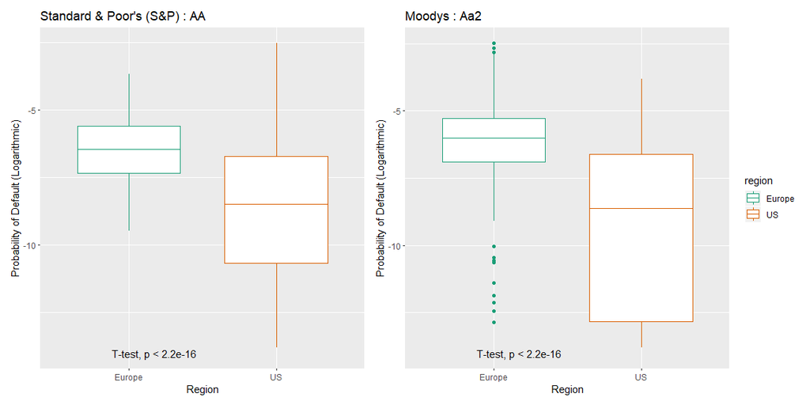

```r
ggsave("output/modelling/part2/figure2.png",  units = "cm",height = 10,width = 20)
# 3)
compare_means(data = df,credit_agency = "sp",category = "AA")$figure +
compare_means(data = df,credit_agency = "moodys",category = "Aa2", title = "Moodys")$figure +
  plot_layout(guides="collect")
```

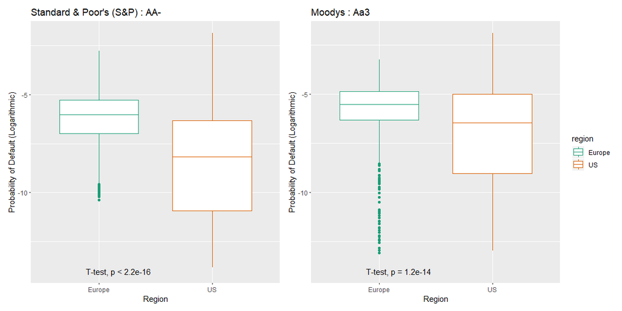

```r
ggsave("output/modelling/part2/figure3.png",  units = "cm",height = 10,width = 20)
# 4)
compare_means(data = df,credit_agency = "sp",category = "AA-")$figure +
compare_means(data = df,credit_agency = "moodys",category = "Aa3", title = "Moodys")$figure  +
  plot_layout(guides="collect")
```

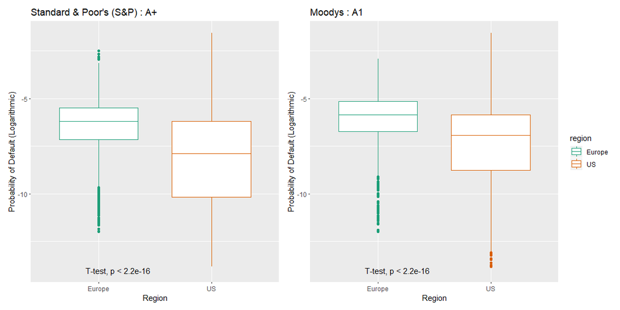

```r
ggsave("output/modelling/part2/figure4.png",  units = "cm",height = 10,width = 20)
# 5)
compare_means(data = df,credit_agency = "sp",category = "A+")$figure +
compare_means(data = df,credit_agency = "moodys",category = "A1", title = "Moodys")$figure +
  plot_layout(guides="collect")
```

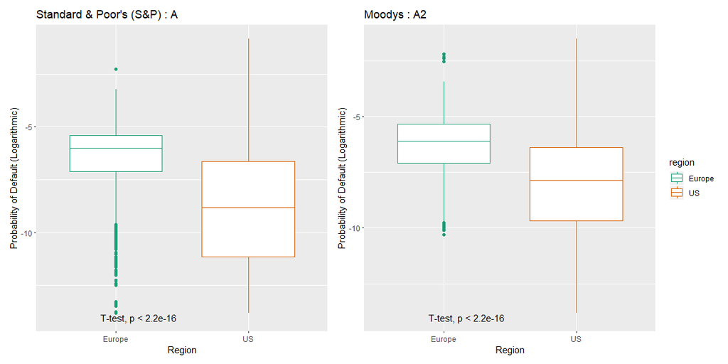

```r
ggsave("output/modelling/part2/figure5.png",  units = "cm",height = 10,width = 20)
# 6)
compare_means(data = df,credit_agency = "sp",category = "A")$figure +
compare_means(data = df,credit_agency = "moodys",category = "A2", title = "Moodys")$figure +
  plot_layout(guides="collect")
```

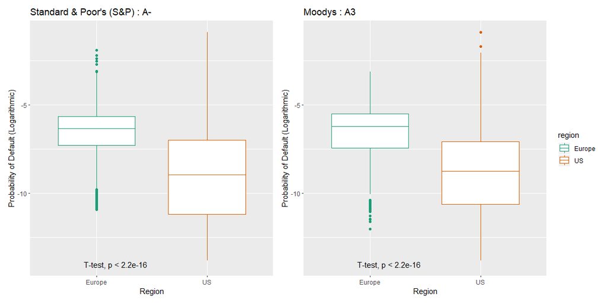

```r
ggsave("output/modelling/part2/figure6.png",  units = "cm",height = 10,width = 20)
# 7)
compare_means(data = df,credit_agency = "sp",category = "A-")$figure +
compare_means(data = df,credit_agency = "moodys",category = "A3", title = "Moodys")$figure +
  plot_layout(guides="collect")
```

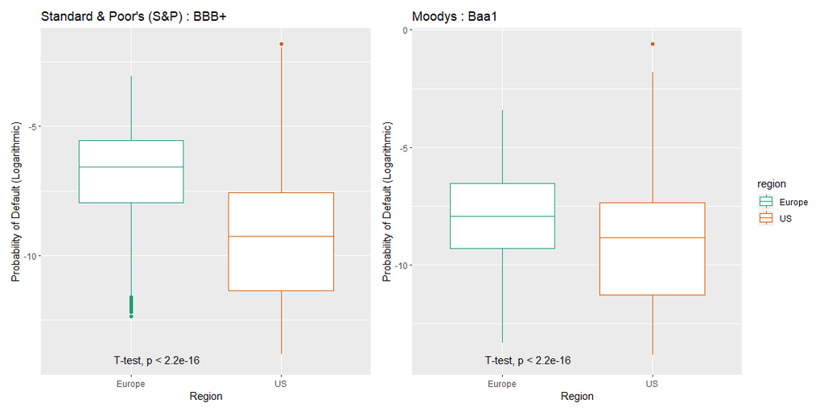

```r
ggsave("output/modelling/part2/figure7.png",  units = "cm",height = 10,width = 20)
# 8)
compare_means(data = df,credit_agency = "sp",category = "BBB+")$figure +
compare_means(data = df,credit_agency = "moodys",category = "Baa1", title = "Moodys")$figure +
  plot_layout(guides="collect")
```

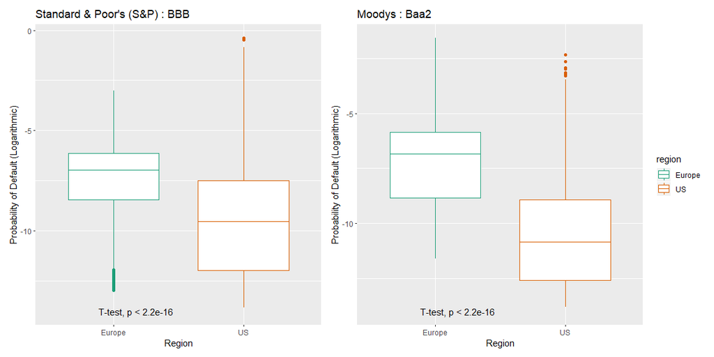

```r
ggsave("output/modelling/part2/figure8.png",  units = "cm",height = 10,width = 20)
# 9)
compare_means(data = df,credit_agency = "sp",category = "BBB")$figure +
compare_means(data = df,credit_agency = "moodys",category = "Baa2", title = "Moodys")$figure +
  plot_layout(guides="collect")
```

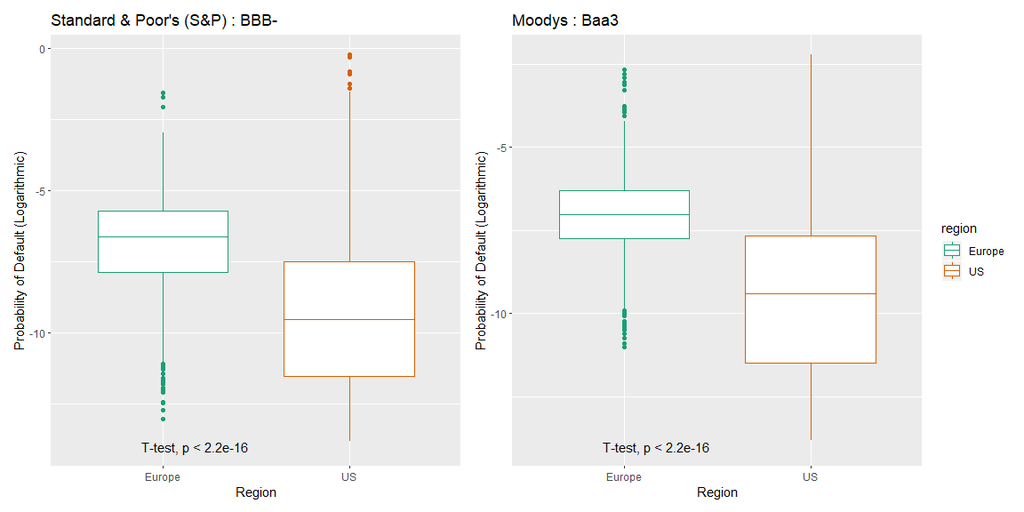

```r
ggsave("output/modelling/part2/figure9.png",  units = "cm",height = 10,width = 20)
# 10)
compare_means(data = df,credit_agency = "sp",category = "BBB-")$figure +
compare_means(data = df,credit_agency = "moodys",category = "Baa3", title = "Moodys")$figure +
  plot_layout(guides="collect")
```

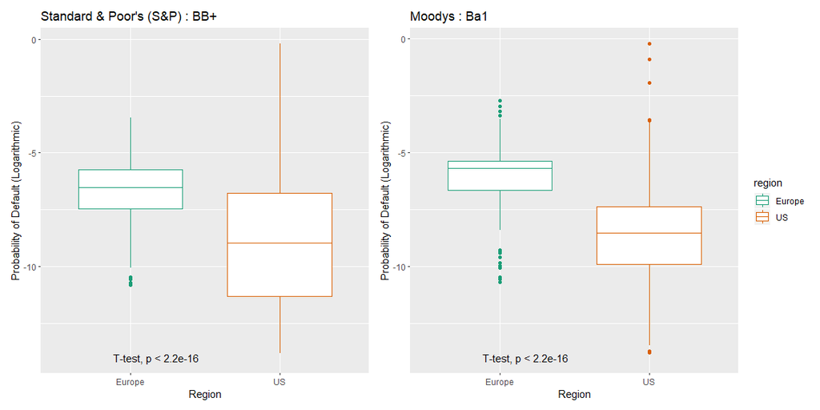

```r
ggsave("output/modelling/part2/figure10.png",  units = "cm",height = 10,width = 20)
# 11)
compare_means(data = df,credit_agency = "sp",category = "BB+")$figure +
compare_means(data = df,credit_agency = "moodys",category = "Ba1", title = "Moodys")$figure +
  plot_layout(guides="collect")
```

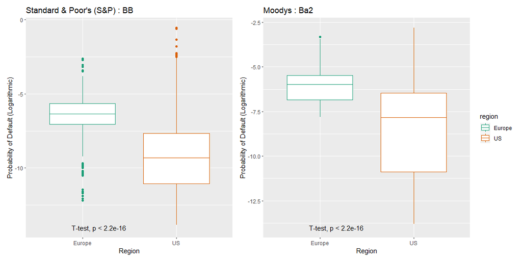

```r
ggsave("output/modelling/part2/figure11.png",  units = "cm",height = 10,width = 20)
# 12)
compare_means(data = df,credit_agency = "sp",category = "BB")$figure +
compare_means(data = df,credit_agency = "moodys",category = "Ba2", title = "Moodys")$figure +
  plot_layout(guides="collect")
```

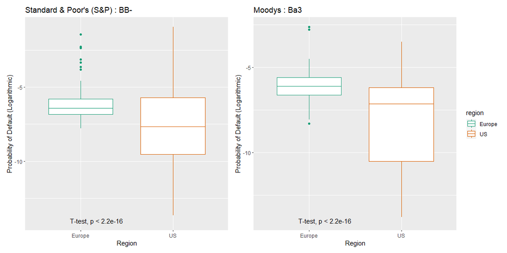

```r
ggsave("output/modelling/part2/figure12.png",  units = "cm",height = 10,width = 20)
# 13)
compare_means(data = df,credit_agency = "sp",category = "BB-")$figure +
compare_means(data = df,credit_agency = "moodys",category = "Ba3", title = "Moodys")$figure +
  plot_layout(guides="collect")
```

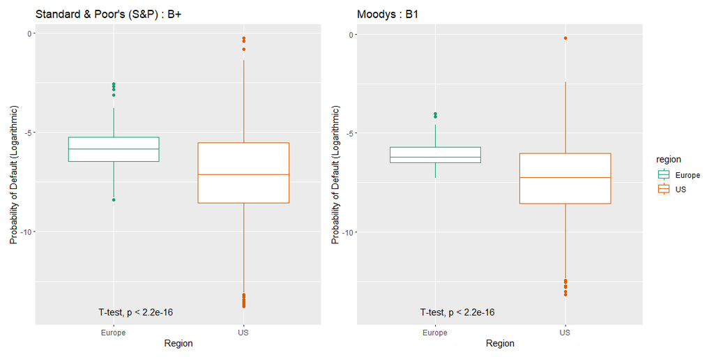

```r
ggsave("output/modelling/part2/figure13.png",  units = "cm",height = 10,width = 20)
# 14)
compare_means(data = df,credit_agency = "sp",category = "B+")$figure +
compare_means(data = df,credit_agency = "moodys",category = "B1", title = "Moodys")$figure +
  plot_layout(guides="collect")
```

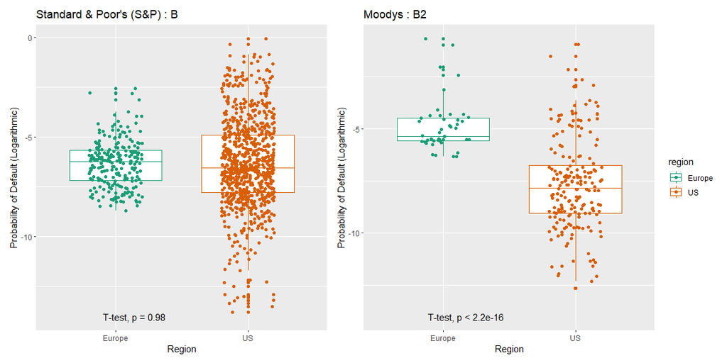

```r
ggsave("output/modelling/part2/figure14.png",  units = "cm",height = 10,width = 20)
# 15)
compare_means(data = df,credit_agency = "sp",category = "B", add="jitter")$figure +
compare_means(data = df,credit_agency = "moodys",category = "B2", title = "Moodys", add="jitter")$figure +
  plot_layout(guides="collect")
```

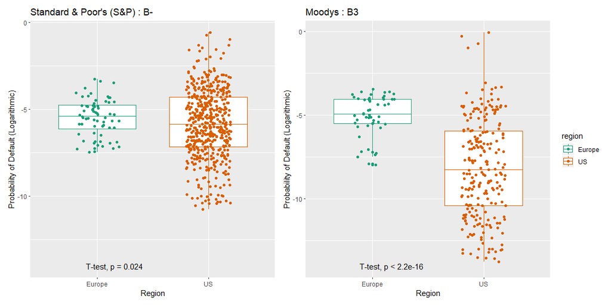

```r
ggsave("output/modelling/part2/figure15.png",  units = "cm",height = 10,width = 20)
# 16)
compare_means(data = df,credit_agency = "sp",category = "B-", add="jitter")$figure +
compare_means(data = df,credit_agency = "moodys",category = "B3", title = "Moodys", add="jitter")$figure +
  plot_layout(guides="collect")
```

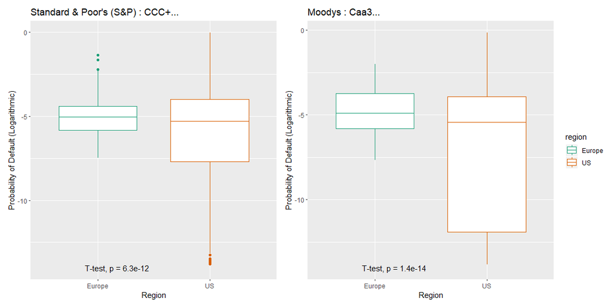

```r
ggsave("output/modelling/part2/figure16.png",  units = "cm",height = 10,width = 20)
# 17)
compare_means(data = df,credit_agency = "sp",category = "CCC+...")$figure +
compare_means(data = df,credit_agency = "moodys",category = "Caa3...", title = "Moodys")$figure +
  plot_layout(guides="collect")
```

```r
ggsave("output/modelling/part2/figure17.png",  units = "cm",height = 10,width = 20)
```

## Helper functions to summarise findings

```r
# sp
for (rating in levels(df$sp)) {
  if (rating == "AAA") {
    # first time
    sp_statistics = compare_means(
      data = df,
      return_statistic =
        TRUE,
      credit_agency = "sp",
      category = rating
    )$statistics
  }
  else{
    out_sp <-
      compare_means(
        data = df,
        return_statistic = TRUE,
        credit_agency = "sp",
        category = rating
      )$statistics
    # update
    sp_statistics <- rbind(sp_statistics, out_sp)

  }
}
# moodys
for (rating in levels(df$moodys)) {
  if (rating == "Aaa") {
    # first time
    moodys_statistics = compare_means(
      data = df,
      return_statistic = TRUE,
      credit_agency = "moodys",
      category = rating
    )$statistics
  }
  else{
    out_moodys <- compare_means(
      data = df,
      return_statistic = TRUE,
      credit_agency = "moodys",
      category = rating
    )$statistics
    # update
    moodys_statistics <- rbind(moodys_statistics, out_moodys)

  }
}
```

## Summarise findings by means of confidence interval

if the confidence interval does not contain the 0 value, it means its significant. You can verify whether this alligns with the p-value. The confidence intervals are at the 95% signiciant level. These two tables contain all information of the analysis. Please take a closer look at the numbers! The figures above tries to give you some more inuition about the reuls, the figure below summarise everyting.

```r
moodys_statistics$order <- 1:17
sp_statistics$order <- 1:17
# look at S&P
reorder(sp_statistics$order, sp_statistics$difference_mean)
```

```
 [1] 1  2  3  4  5  6  7  8  9  10 11 12 13 14 15 16 17
attr(,"scores")
          1           2           3           4           5
2.708013676 2.512010339 2.365100922 2.367991162 1.700294098
          6           7           8           9          10
2.496372593 2.576915278 2.594922164 2.223924332 2.523065793
         11          12          13          14          15
2.333867161 2.506539102 1.455109816 1.285345534 0.002222722
         16          17
0.359343772 0.989970247
Levels: 15 16 17 14 13 5 9 11 3 4 6 12 2 10 7 8 1
```

```r
# Moodys
moodys_statistics
```

| rating_agency | rating_category | t_stat | p_value | conf_lower_bound | conf_upper_bound | sd_error | means_europe | means_us | difference_mean | order |
| --- | --- | --- | --- | --- | --- | --- | --- | --- | --- | --- |
| moodys | Aaa | 10.638119 | 5.018621e-18 | 2.5007640 | 3.647723 | 0.28898374 | -5.643689 | -8.717932 | 3.074243 | 1 |
| moodys | Aa1 | 4.706399 | 6.844654e-02 | -0.2665719 | 2.517243 | 0.23910752 | -5.788573 | -6.913908 | 1.125335 | 2 |
| moodys | Aa2 | 15.709159 | 1.610656e-42 | 2.6121952 | 3.359874 | 0.19008240 | -6.207809 | -9.193844 | 2.986035 | 3 |
| moodys | Aa3 | 7.837179 | 1.240620e-14 | 0.7944650 | 1.325258 | 0.13523511 | -5.994662 | -7.054524 | 1.059862 | 4 |
| moodys | A1 | 12.686023 | 1.997677e-35 | 0.9377727 | 1.280754 | 0.08743980 | -6.242172 | -7.351436 | 1.109263 | 5 |
| moodys | A2 | 25.626358 | 1.731238e-127 | 1.7467798 | 2.036270 | 0.07381170 | -6.297275 | -8.188800 | 1.891525 | 6 |
| moodys | A3 | 31.490578 | 1.281890e-171 | 2.2506695 | 2.549655 | 0.07621842 | -6.530914 | -8.931077 | 2.400162 | 7 |
| moodys | Baa1 | 11.392481 | 4.297682e-28 | 0.9289308 | 1.315633 | 0.09851076 | -8.058715 | -9.180997 | 1.122282 | 8 |
| moodys | Baa2 | 32.991505 | 5.720521e-150 | 3.0426996 | 3.427693 | 0.09806149 | -7.303781 | -10.538977 | 3.235196 | 9 |
| moodys | Baa3 | 25.605111 | 6.070048e-105 | 2.3503706 | 2.740687 | 0.09941486 | -7.031239 | -9.576768 | 2.545529 | 10 |

[output cut: 7 more lines]

```r
sp_statistics
```

| rating_agency | rating_category | t_stat | p_value | conf_lower_bound | conf_upper_bound | sd_error | means_europe | means_us | difference_mean | order |
| --- | --- | --- | --- | --- | --- | --- | --- | --- | --- | --- |
| sp | AAA | 13.44310042 | 3.418571e-33 | 2.31174891 | 3.1042784 | 0.20144264 | -7.082716 | -9.790729 | 2.708013676 | 1 |
| sp | AA+ | 15.49570263 | 8.855333e-42 | 2.19319936 | 2.8308213 | 0.16211013 | -6.334466 | -8.846477 | 2.512010339 | 2 |
| sp | AA | 15.31466835 | 2.349329e-42 | 2.06153899 | 2.6686629 | 0.15443370 | -6.478904 | -8.844005 | 2.365100922 | 3 |
| sp | AA- | 29.23986646 | 3.932257e-150 | 2.20913976 | 2.5268426 | 0.08098502 | -6.207180 | -8.575171 | 2.367991162 | 4 |
| sp | A+ | 27.30955714 | 1.378903e-150 | 1.57822930 | 1.8223589 | 0.06226004 | -6.498050 | -8.198344 | 1.700294098 | 5 |
| sp | A | 48.66021209 | 0.000000e+00 | 2.39579956 | 2.5969456 | 0.05130213 | -6.389440 | -8.885813 | 2.496372593 | 6 |
| sp | A- | 56.14269909 | 0.000000e+00 | 2.48693983 | 2.6668907 | 0.04589938 | -6.525083 | -9.101998 | 2.576915278 | 7 |
| sp | BBB+ | 58.20046870 | 0.000000e+00 | 2.50751919 | 2.6823251 | 0.04458593 | -6.839849 | -9.434771 | 2.594922164 | 8 |
| sp | BBB | 52.55713423 | 0.000000e+00 | 2.14097659 | 2.3068721 | 0.04231441 | -7.391599 | -9.615524 | 2.223924332 | 9 |
| sp | BBB- | 50.08724696 | 0.000000e+00 | 2.42430172 | 2.6218299 | 0.05037342 | -6.940045 | -9.463111 | 2.523065793 | 10 |

[output cut: 7 more lines]

## Summarise by means of confidence interval

The figure below shows the difference in log probability of default between Europe and US. As the boxplot figures from above indicate, the log probability of default for Europe is significantly higher than US for almost all rating categories. The difference is calculated as log probability of default for Europe - log probabiity of default for the US which will yield a positive number. The dot in the middle of the confdince interval represent the mean (point estimate) and the bounds represents the amount of uncertainty about the number.

**Brief refresher on confidence intervals**

please also watch these videos:

- https://www.youtube.com/watch?v=TqOeMYtOc1w
- https://www.youtube.com/watch?v=hxZ6uooEJOk&t=808s
- https://www.youtube.com/watch?v=hlM7zdf7zwU

The higher the number, the larger the difference between the probability of default for Europe and the US. The smaller the confidence interval (die horizontale staven), the more certain you are about your point estimate (mean = the point in the middle).

I would include this figure in the thesis! Confidence intervals are much more informative than p-values as they give an idea about the practical relevance (the amount of the difference in this case). Remember, if you have a huge amount of data, almost everything becomes statistically significant (which is the case in this analysis). The real question you should ask ,besides wether something is staticially significant, is it also economically relevant? Who cares about a statstically siginciant difference if it’s only 0.0000001 (spoiler: nobody does).

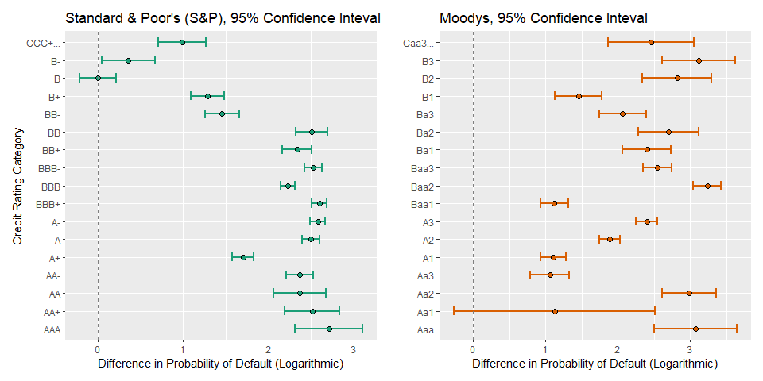

```r
# make summary figure
p_sp <- ggplot() +
  geom_errorbarh(
    data = sp_statistics,
    mapping = aes(y = reorder(rating_category,order),
                  xmin = conf_lower_bound,
                  xmax = conf_upper_bound),
    height = 0.5,
    size = 1,
    color = PALETTE[1]
  ) + geom_point(
    data = sp_statistics,
    mapping = aes(y = reorder(rating_category,order), x = difference_mean),
    size = 2,
    shape = 21,
    fill = PALETTE[1]
  ) + geom_vline(xintercept = 0, linetype = 2, color = "gray50") +
  labs(x = "Difference in Probability of Default (Logarithmic)",
           y = "Credit Rating Category") + ggtitle("Standard & Poor's (S&P), 95% Confidence Inteval")
p_moodys <- ggplot() +
  geom_errorbarh(
    data = moodys_statistics,
    mapping = aes(y = reorder(rating_category,order),
                  xmin = conf_lower_bound,
                  xmax = conf_upper_bound),
    height = 0.5,
    size = 1,
    color = PALETTE[2]
  ) + geom_point(
    data = moodys_statistics,
    mapping = aes(y = reorder(rating_category,order), x = difference_mean),
    size = 2,
    shape = 21,
    fill = PALETTE[2]
  ) + geom_vline(xintercept = 0, linetype = 2, color = "gray50") +
  labs(x = "Difference in Probability of Default (Logarithmic)",
           y = "") + ggtitle("Moodys, 95% Confidence Inteval")
# plot figure
p_sp + p_moodys
```

```r
ggsave("output/modelling/part2/figure18.png",
       units = "cm",
       height = 14,
       width = 30)
```